# Untitled

Shilpa Khichar

15 December 2016

clear tables from Global Environment

```r
rm(list=ls())
```

Reading data from CSV file to R dataset: Printing first 6 rows of the dataset choosen, for better understanding of attributes

```r
getwd()
```

```
## [1] "F:/B.I.Sem2/computational intelligence/Project"
```

```r
#Online_news_popularity <- read.csv(file.path(getwd(),  "OnlineNewsPopularity.csv"), header=TRUE, sep=",", encoding="UTF-8")

Online_news_popularity <- read.csv(file.path("C:\\Users\\hp\\Documents\\OnlineNewsPopularity.csv"), header=TRUE, sep=",", encoding="UTF-8")
head(Online_news_popularity)
```

```
##                                                              url timedelta
## 1   http://mashable.com/2013/01/07/amazon-instant-video-browser/       731
## 2    http://mashable.com/2013/01/07/ap-samsung-sponsored-tweets/       731
## 3 http://mashable.com/2013/01/07/apple-40-billion-app-downloads/       731
## 4       http://mashable.com/2013/01/07/astronaut-notre-dame-bcs/       731
## 5               http://mashable.com/2013/01/07/att-u-verse-apps/       731
## 6               http://mashable.com/2013/01/07/beewi-smart-toys/       731
##   n_tokens_title n_tokens_content n_unique_tokens n_non_stop_words
## 1             12              219       0.6635945                1
## 2              9              255       0.6047431                1
## 3              9              211       0.5751295                1
## 4              9              531       0.5037879                1
## 5             13             1072       0.4156456                1
## 6             10              370       0.5598886                1
##   n_non_stop_unique_tokens num_hrefs num_self_hrefs num_imgs num_videos
```

[output cut: 111 more lines]

so next we modify our classification range ,for balanced enteries:

```r
Online_news_popularity$class <- with( Online_news_popularity, ifelse(shares < 1500 ,1 ,2))
```

next we check the frequencies of each label

```r
table(Online_news_popularity$class)
```

```
##
##     1     2
## 20082 19562
```

we want our data to be stable i.e. more or less same frequencies… if there is huge difference in frequencies then there are descripancies in the results, because the lable with more frequency draws most predictions towards itself.

Removing non-predictive variables : “url”, “timedelta”,

Removing Near Zero Variance variable:“kw_min_max”  
Removing Highly coorelated variables:“kw_avg_avg” “data_channel_is_world” “rate_negative_words” “LDA_00”  
“kw_min_min”  
“self_reference_max_shares” “kw_max_min”  
“self_reference_min_shares” “n_non_stop_words”  
“n_unique_tokens”

```r
usefull <- names(Online_news_popularity) %in%
c("class", "n_tokens_content","n_non_stop_unique_tokens", "data_channel_is_entertainment","data_channel_is_socmed","kw_min_avg","kw_max_avg", "self_reference_avg_sharess", "is_weekend", "LDA_02","LDA_04","shares")
online_usefull <- Online_news_popularity[usefull]
```

```r
str(online_usefull)
```

```
## 'data.frame':    39644 obs. of  12 variables:
##  $ n_tokens_content             : num  219 255 211 531 1072 ...
##  $ n_non_stop_unique_tokens     : num  0.815 0.792 0.664 0.666 0.541 ...
##  $ data_channel_is_entertainment: num  1 0 0 1 0 0 0 0 0 0 ...
##  $ data_channel_is_socmed       : num  0 0 0 0 0 0 0 0 0 0 ...
##  $ kw_min_avg                   : num  0 0 0 0 0 0 0 0 0 0 ...
##  $ kw_max_avg                   : num  0 0 0 0 0 0 0 0 0 0 ...
##  $ self_reference_avg_sharess   : num  496 0 918 0 3151 ...
##  $ is_weekend                   : num  0 0 0 0 0 0 0 0 0 0 ...
##  $ LDA_02                       : num  0.04 0.0501 0.0334 0.4947 0.0286 ...
##  $ LDA_04                       : num  0.0401 0.05 0.6822 0.0286 0.8854 ...
##  $ shares                       : int  593 711 1500 1200 505 855 556 891 3600 710 ...
##  $ class                        : num  1 1 2 1 1 1 1 1 2 1 ...
```

class variable is normalized here

```r
library(caret)
preProcValues <- preProcess(online_usefull, method = c("range"))

set.seed(20)



indxTrain <- createDataPartition(y = online_usefull$class, p = 0.02)
Online_train <- predict(preProcValues, online_usefull[indxTrain$Resample1, ])
indxTrain <- createDataPartition(y = online_usefull$class, p = 0.02)
Online_test <- predict(preProcValues,online_usefull[indxTrain$Resample1, ])

Online_test_crop <- as.data.frame( subset(Online_train, select = c("n_tokens_content", "n_non_stop_unique_tokens", "LDA_02" , "LDA_04","class","shares") ))
```

## neural network on online news popularity:

```r
library(neuralnet)

result_matrix = NULL
```

# backprop neural network model

```r
nn = neuralnet(class ~ n_tokens_content +n_non_stop_unique_tokens+ LDA_02 +LDA_04, data = Online_train , hidden = 3, learningrate=0.01,algorithm = 'backprop' ,err.fct = "sse", stepmax = 2e05, linear.output = FALSE)
plot(nn)
nn.results <- compute(nn, Online_test_crop[, 1:4] )
results <- data.frame(actual = Online_test_crop$class, prediction = nn.results$net.result)
results[1:20,  ]
```

```
##     actual   prediction
## 8        0 0.5491014617
## 22       0 0.2848393983
## 77       0 0.4971304674
## 120      0 0.5997569051
## 136      1 0.6369493703
## 159      1 0.2190758148
## 166      1 0.6031124766
## 225      1 0.6650024254
## 230      1 0.6813414199
## 264      1 0.6169128511
## 326      1 0.6753772360
## 405      0 0.5058718800
## 410      0 0.5047550112
## 455      0 0.5129700520
## 593      0 0.6178426180
## 831      0 0.5248585820
## 881      1 0.5052546523
## 931      1 0.5696902127
## 969      1 0.5150844018
## 973      0 0.4657147248
```

```r
nn1 = ifelse(nn.results$net.result>0.5 , 1, 0)

misClasificationError = mean(Online_test_crop != nn1)
OutputVsPred = cbind(Online_train$class, nn1)


cm <- table(Online_test_crop$class, nn1)

confusionMatrix(cm)
```

```
## Confusion Matrix and Statistics
##
##    nn1
##       0   1
##   0 151 241
##   1  98 303
##
##                Accuracy : 0.5725095
##                  95% CI : (0.5372303, 0.6072476)
##     No Information Rate : 0.6860025
##     P-Value [Acc > NIR] : 1
##
##                   Kappa : 0.1413939
##  Mcnemar's Test P-Value : 0.00000000000001234915
##
##             Sensitivity : 0.6064257
##             Specificity : 0.5569853
##          Pos Pred Value : 0.3852041
##          Neg Pred Value : 0.7556110
##              Prevalence : 0.3139975
##          Detection Rate : 0.1904161
##    Detection Prevalence : 0.4943253
##       Balanced Accuracy : 0.5817055
##
##        'Positive' Class : 0
##
```

```r
n = sum(cm) # number of instances
nc = nrow(cm) # number of classes
diag = diag(cm) # number of correctly classified instances per class
rowsums = apply(cm, 1, sum) # number of instances per class
colsums = apply(cm, 2, sum) # number of predictions per class
p = rowsums / n # distribution of instances over the actual classes
q = colsums / n # distribution of instances over the predicted classes
accuracy = sum(diag) / n
sensitivity = diag / rowsums
precision = diag / colsums
recall = diag / rowsums
f1 = 2 * precision * recall / (precision + recall)
expAccuracy = sum(p*q)
kappa = (accuracy - expAccuracy) / (1 - expAccuracy)

 result_matrix= rbind(result_matrix, data.frame( accuracy, precision, recall, f1, kappa))
```

# resilient backpropagation with weight backtracking

```r
nn = neuralnet(class ~ n_tokens_content +n_non_stop_unique_tokens+ LDA_02 +LDA_04, data = Online_train , hidden = 3, learningrate=0.01,algorithm = 'rprop+' ,err.fct = "sse",  linear.output = FALSE)
plot(nn)
nn.results <- compute(nn, Online_test_crop[, 1:4] )
results <- data.frame(actual = Online_test_crop$class, prediction = nn.results$net.result)
results[1:20,  ]
```

```
##     actual   prediction
## 8        0 0.5231636547
## 22       0 0.3402628413
## 77       0 0.5214228571
## 120      0 0.5242476200
## 136      1 0.7359874740
## 159      1 0.2003539308
## 166      1 0.5376011607
## 225      1 0.7798071579
## 230      1 0.7814466254
## 264      1 0.5404352397
## 326      1 0.7806446343
## 405      0 0.5300004723
## 410      0 0.5294409106
## 455      0 0.5305636625
## 593      0 0.5880303219
## 831      0 0.5135381808
## 881      1 0.5021051552
## 931      1 0.5202978616
## 969      1 0.5289186612
## 973      0 0.4708480787
```

```r
nn1 = ifelse(nn.results$net.result>0.5 , 1, 0)

misClasificationError = mean(Online_test_crop != nn1)
OutputVsPred = cbind(Online_train$class, nn1)


cm <- table(Online_test_crop$class, nn1)

confusionMatrix(cm)
```

```
## Confusion Matrix and Statistics
##
##    nn1
##       0   1
##   0 146 246
##   1  85 316
##
##                Accuracy : 0.5825977
##                  95% CI : (0.5473908, 0.6171883)
##     No Information Rate : 0.7087011
##     P-Value [Acc > NIR] : 1
##
##                   Kappa : 0.161222
##  Mcnemar's Test P-Value : <0.0000000000000002
##
##             Sensitivity : 0.6320346
##             Specificity : 0.5622776
##          Pos Pred Value : 0.3724490
##          Neg Pred Value : 0.7880299
##              Prevalence : 0.2912989
##          Detection Rate : 0.1841110
##    Detection Prevalence : 0.4943253
##       Balanced Accuracy : 0.5971561
##
##        'Positive' Class : 0
##
```

```r
n = sum(cm)
nc = nrow(cm)
diag = diag(cm)
rowsums = apply(cm, 1, sum)
colsums = apply(cm, 2, sum)
p = rowsums / n
q = colsums / n
accuracy = sum(diag) / n
sensitivity = diag / rowsums
precision = diag / colsums
recall = diag / rowsums
f1 = 2 * precision * recall / (precision + recall)
expAccuracy = sum(p*q)
kappa = (accuracy - expAccuracy) / (1 - expAccuracy)

 result_matrix= rbind(result_matrix, data.frame( accuracy, precision, recall, f1, kappa))
```

# resilient backpropagation without weight backtracking

```r
nn = neuralnet(class ~ n_tokens_content +n_non_stop_unique_tokens+ LDA_02 +LDA_04, data = Online_train , hidden = 3, learningrate=0.01,algorithm = 'rprop-' ,err.fct = "sse",  linear.output = FALSE)
plot(nn)
nn.results <- compute(nn, Online_test_crop[, 1:4] )
results <- data.frame(actual = Online_test_crop$class, prediction = nn.results$net.result)
results[1:20,  ]
```

```
##     actual   prediction
## 8        0 0.5420385640
## 22       0 0.3149190311
## 77       0 0.5120725145
## 120      0 0.4699288739
## 136      1 0.5959595031
## 159      1 0.1546415392
## 166      1 0.6019613104
## 225      1 0.6064890527
## 230      1 0.6272770096
## 264      1 0.5846690447
## 326      1 0.6089182037
## 405      0 0.5168381473
## 410      0 0.5010678065
## 455      0 0.5231325549
## 593      0 0.6005283540
## 831      0 0.4510776561
## 881      1 0.4845791982
## 931      1 0.5784624161
## 969      1 0.5120663432
## 973      0 0.4458683683
```

```r
nn1 = ifelse(nn.results$net.result>0.5 , 1, 0)

misClasificationError = mean(Online_test_crop != nn1)
OutputVsPred = cbind(Online_train$class, nn1)


cm <- table(Online_test_crop$class, nn1)

confusionMatrix(cm)
```

```
## Confusion Matrix and Statistics
##
##    nn1
##       0   1
##   0 144 248
##   1  80 321
##
##                Accuracy : 0.5863808
##                  95% CI : (0.5512048, 0.6209123)
##     No Information Rate : 0.7175284
##     P-Value [Acc > NIR] : 1
##
##                   Kappa : 0.1686568
##  Mcnemar's Test P-Value : <0.0000000000000002
##
##             Sensitivity : 0.6428571
##             Specificity : 0.5641476
##          Pos Pred Value : 0.3673469
##          Neg Pred Value : 0.8004988
##              Prevalence : 0.2824716
##          Detection Rate : 0.1815889
##    Detection Prevalence : 0.4943253
##       Balanced Accuracy : 0.6035024
##
##        'Positive' Class : 0
##
```

```r
n = sum(cm)
nc = nrow(cm)
diag = diag(cm)
rowsums = apply(cm, 1, sum)
colsums = apply(cm, 2, sum)
p = rowsums / n
q = colsums / n
accuracy = sum(diag) / n
sensitivity = diag / rowsums
precision = diag / colsums
recall = diag / rowsums
f1 = 2 * precision * recall / (precision + recall)
expAccuracy = sum(p*q)
kappa = (accuracy - expAccuracy) / (1 - expAccuracy)

 result_matrix= rbind(result_matrix, data.frame( accuracy, precision, recall, f1, kappa))
```

```r
nn = neuralnet(class ~ n_tokens_content +n_non_stop_unique_tokens+ LDA_02 +LDA_04, data = Online_train , hidden = 3, learningrate=0.01,algorithm = 'sag' ,err.fct = "sse",  linear.output = FALSE)
plot(nn)
nn.results <- compute(nn, Online_test_crop[, 1:4] )
results <- data.frame(actual = Online_test_crop$class, prediction = nn.results$net.result)
results[1:20,  ]
```

```
##     actual   prediction
## 8        0 0.6385763922
## 22       0 0.3607561337
## 77       0 0.5126006739
## 120      0 0.5303873742
## 136      1 0.6549313532
## 159      1 0.2322195777
## 166      1 0.5665028326
## 225      1 0.6690013042
## 230      1 0.7120297880
## 264      1 0.5806013057
## 326      1 0.6643377742
## 405      0 0.5221500220
## 410      0 0.5222757849
## 455      0 0.5240014230
## 593      0 0.6083882918
## 831      0 0.5336051267
## 881      1 0.5201134865
## 931      1 0.5499460622
## 969      1 0.5255000051
## 973      0 0.5102664317
```

```r
nn1 = ifelse(nn.results$net.result>0.5 , 1, 0)

misClasificationError = mean(Online_test_crop != nn1)
OutputVsPred = cbind(Online_train$class, nn1)


cm <- table(Online_test_crop$class, nn1)

confusionMatrix(cm)
```

```
## Confusion Matrix and Statistics
##
##    nn1
##       0   1
##   0 147 245
##   1  87 314
##
##                Accuracy : 0.5813367
##                  95% CI : (0.54612, 0.6159465)
##     No Information Rate : 0.704918
##     P-Value [Acc > NIR] : 1
##
##                   Kappa : 0.1587605
##  Mcnemar's Test P-Value : <0.0000000000000002
##
##             Sensitivity : 0.6282051
##             Specificity : 0.5617174
##          Pos Pred Value : 0.3750000
##          Neg Pred Value : 0.7830424
##              Prevalence : 0.2950820
##          Detection Rate : 0.1853720
##    Detection Prevalence : 0.4943253
##       Balanced Accuracy : 0.5949612
##
##        'Positive' Class : 0
##
```

```r
n = sum(cm)
nc = nrow(cm)
diag = diag(cm)
rowsums = apply(cm, 1, sum)
colsums = apply(cm, 2, sum)
p = rowsums / n
q = colsums / n
accuracy = sum(diag) / n
sensitivity = diag / rowsums
precision = diag / colsums
recall = diag / rowsums
f1 = 2 * precision * recall / (precision + recall)
expAccuracy = sum(p*q)
kappa = (accuracy - expAccuracy) / (1 - expAccuracy)

 result_matrix= rbind(result_matrix, data.frame( accuracy, precision, recall, f1, kappa))
```

```r
nn = neuralnet(class ~ n_tokens_content +n_non_stop_unique_tokens+ LDA_02 +LDA_04, data = Online_train , hidden = 3, learningrate=0.01,algorithm = 'slr' ,err.fct = "sse",  linear.output = FALSE)
plot(nn)
nn.results <- compute(nn, Online_test_crop[, 1:4] )
results <- data.frame(actual = Online_test_crop$class, prediction = nn.results$net.result)
results[1:20,  ]
```

```
##     actual   prediction
## 8        0 0.5497022363
## 22       0 0.2139194824
## 77       0 0.5114240190
## 120      0 0.2956261779
## 136      1 0.6063010538
## 159      1 0.3062725843
## 166      1 0.6143360938
## 225      1 0.6061538924
## 230      1 0.6050024369
## 264      1 0.5975256697
## 326      1 0.6070027993
## 405      0 0.5148612363
## 410      0 0.5180866579
## 455      0 0.5153678619
## 593      0 0.6096841944
## 831      0 0.5192870616
## 881      1 0.5161270410
## 931      1 0.4913029728
## 969      1 0.5218611540
## 973      0 0.2418377894
```

```r
nn1 = ifelse(nn.results$net.result>0.5 , 1, 0)

misClasificationError = mean(Online_test_crop != nn1)
OutputVsPred = cbind(Online_train$class, nn1)


cm <- table(Online_test_crop$class, nn1)

confusionMatrix(cm)
```

```
## Confusion Matrix and Statistics
##
##    nn1
##       0   1
##   0 121 271
##   1  64 337
##
##                Accuracy : 0.5775536
##                  95% CI : (0.5423087, 0.6122198)
##     No Information Rate : 0.7667087
##     P-Value [Acc > NIR] : 1
##
##                   Kappa : 0.1499611
##  Mcnemar's Test P-Value : <0.0000000000000002
##
##             Sensitivity : 0.6540541
##             Specificity : 0.5542763
##          Pos Pred Value : 0.3086735
##          Neg Pred Value : 0.8403990
##              Prevalence : 0.2332913
##          Detection Rate : 0.1525851
##    Detection Prevalence : 0.4943253
##       Balanced Accuracy : 0.6041652
##
##        'Positive' Class : 0
##
```

```r
n = sum(cm)
nc = nrow(cm)
diag = diag(cm)
rowsums = apply(cm, 1, sum)
colsums = apply(cm, 2, sum)
p = rowsums / n
q = colsums / n
accuracy = sum(diag) / n
sensitivity = diag / rowsums
precision = diag / colsums
recall = diag / rowsums
f1 = 2 * precision * recall / (precision + recall)
expAccuracy = sum(p*q)
kappa = (accuracy - expAccuracy) / (1 - expAccuracy)

 result_matrix= rbind(result_matrix, data.frame( accuracy, precision, recall, f1, kappa))
```

```r
colnames(result_matrix) <- c("Accuracy", "Precision", "Recall", "F1", "Kappa")
rownames(result_matrix) <- c("backprop 0" , "backprop 1", "rprop+ 0","rprop+ 1 ","rprop- 0","rprop- 1","sag 0","sag 1","slr 0","slr 1")
result_matrix
```

```
##                Accuracy    Precision       Recall           F1
## backprop 0 0.5725094578 0.6064257028 0.3852040816 0.4711388456
## backprop 1 0.5725094578 0.5569852941 0.7556109726 0.6412698413
## rprop+ 0   0.5825977301 0.6320346320 0.3724489796 0.4686998395
## rprop+ 1   0.5825977301 0.5622775801 0.7880299252 0.6562824507
## rprop- 0   0.5863808323 0.6428571429 0.3673469388 0.4675324675
## rprop- 1   0.5863808323 0.5641476274 0.8004987531 0.6618556701
## sag 0      0.5813366961 0.6282051282 0.3750000000 0.4696485623
## sag 1      0.5813366961 0.5617173524 0.7830423940 0.6541666667
## slr 0      0.5775535939 0.6540540541 0.3086734694 0.4194107452
## slr 1      0.5775535939 0.5542763158 0.8403990025 0.6679881070
##                   Kappa
## backprop 0 0.1413938811
## backprop 1 0.1413938811
## rprop+ 0   0.1612219790
## rprop+ 1   0.1612219790
## rprop- 0   0.1686568309
## rprop- 1   0.1686568309
## sag 0      0.1587604885
## sag 1      0.1587604885
## slr 0      0.1499611226
## slr 1      0.1499611226
```

# Conclusion

From the result matrix we can see that rsileint back propagation Neural network model performs best on our dataset. as RPROP is A Fast Adaptive Learning Algorithm.It overcome the inherent disadvantages of the pure gradient-descent technique of the original backpropagation procedure, RPROP performs an adaptation of the weight update-values according to the behaviour of the errorfunction.Hence performs better.

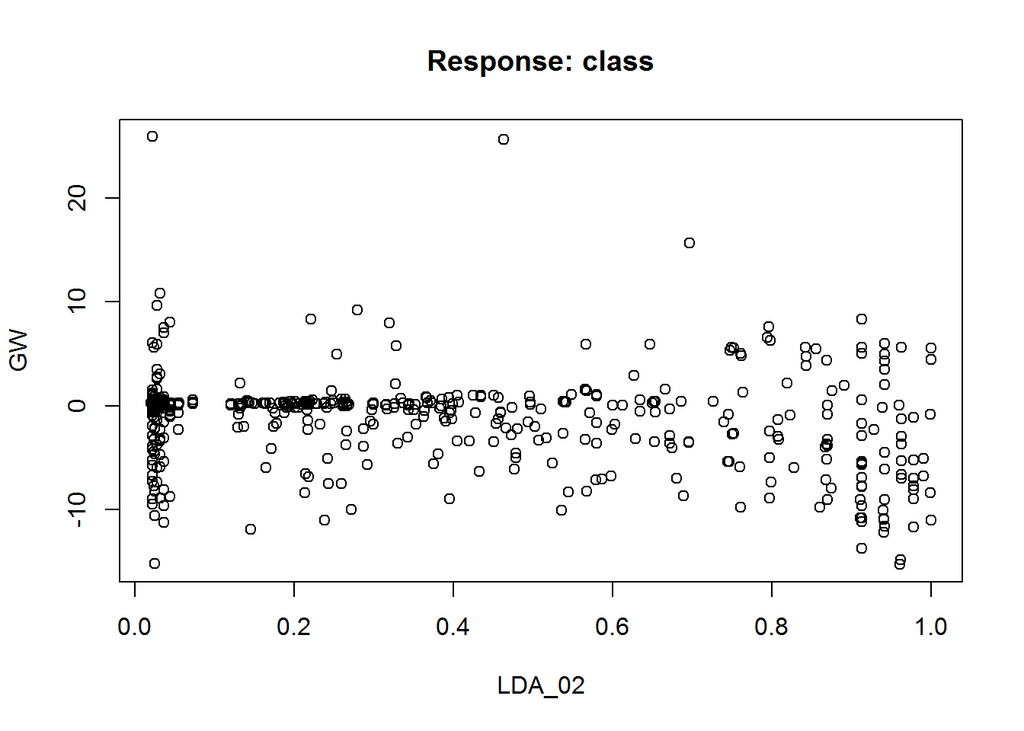

```r
gwplot(nn, selected.covariate="LDA_02")
```

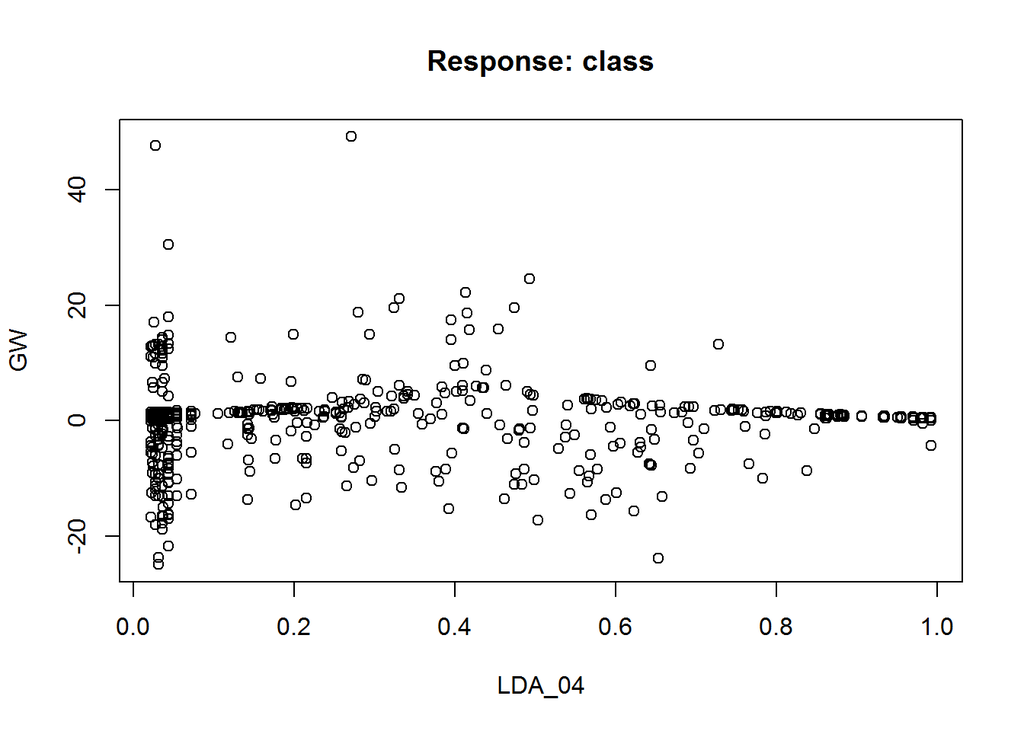

```r
gwplot(nn, selected.covariate="LDA_04")
```

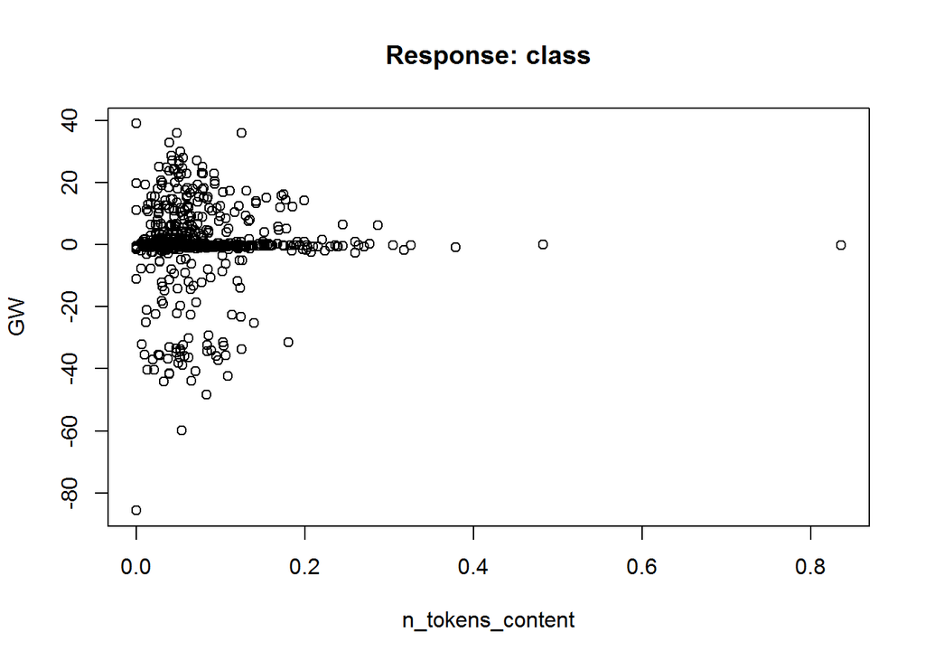

```r
gwplot(nn, selected.covariate="n_tokens_content")
```

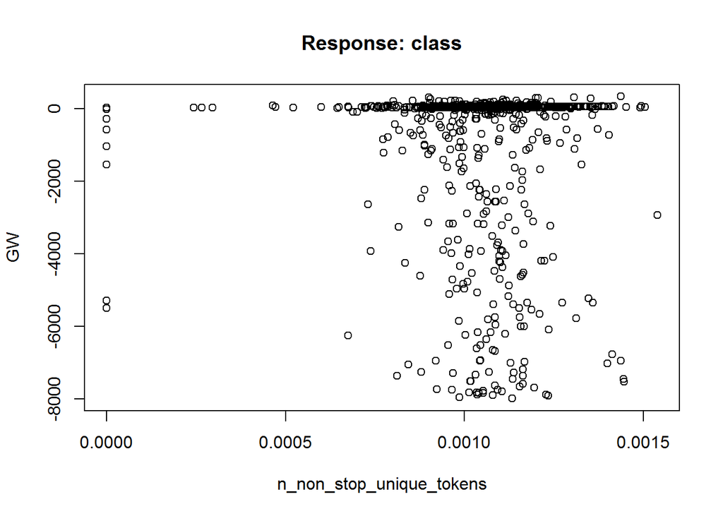

```r
gwplot(nn, selected.covariate="n_non_stop_unique_tokens")
```

```r
##online_test_crop has same rows as online_test, but with less number of columns.
## order function is used to find the entery with maximum number of shares
order_asc<-Online_test_crop[order(-Online_test_crop$share),]
## implementing backprpagation neural network model
nn = neuralnet(class ~ n_tokens_content +n_non_stop_unique_tokens+ LDA_02 +LDA_04, data = order_asc , hidden = 3, learningrate=0.01,algorithm = 'backprop' ,err.fct = "sse",  linear.output = FALSE)
plot(nn)
## compution prediction for just 1 entery i.e. highest shares entery
nn.results <- compute(nn, order_asc[1, 1:4] )
nn.results
```

```
## $neurons
## $neurons[[1]]
##       1 n_tokens_content n_non_stop_unique_tokens        LDA_02
## 28990 1    0.04059476044           0.001171171166 0.02176155049
##              LDA_04
## 28990 0.07703668314
##
## $neurons[[2]]
##       [,1]         [,2]         [,3]         [,4]
## 28990    1 0.3269728906 0.5031093075 0.9717951493
##
##
## $net.result
##               [,1]
## 28990 0.5196095235
```

```r
order_asc[1,]
```

```
##       n_tokens_content n_non_stop_unique_tokens        LDA_02
## 28990    0.04059476044           0.001171171166 0.02176155049
##              LDA_04 class       shares
## 28990 0.07703668314     1 0.1249841397
```

```r
## here we can see that the entry was correctly predicted, we can check the model again our entery by comparing values of rest of the column values
results <- data.frame(actual = order_asc[1,]$class, prediction = nn.results$net.result[1,])
results
```

```
##       actual   prediction
## 28990      1 0.5196095235
```

```r
nn1 = ifelse(nn.results$net.result>0.5 , 1, 0)
misClasificationError = mean(order_asc[1, 1:4] != nn1)
OutputVsPred = cbind(order_asc[1,]$class, nn1)
OutputVsPred
```

```
##       [,1] [,2]
## 28990    1    1
```

```r
confusion_Matrix <- table(order_asc[1,]$class, nn1)

## performance measures connot be calculated because at least 2 factors are required and here we are just checking for class = 1 ..maximum shares.
```